# qaa answers

2022-08-08

## FASTQA ASSIGNMENT:

Assignment Pipeline Part 1: Demultiplexed Zipped Fastq files -> Run Fastqc

Part 2: Fastqc files -> cutadapt (bash) -> trimmomatic(bash) -> calculate read length distribution (bash) & plot (R)

Part 3: trimmomatic files -> STAR (bash) -> count # of mapped/unmapped reads (python) -> HTSEQ(BASH)

#BASH COMMAND

#create new conda environment called QAA conda create -name QAA

#open interactive talapas session srun –account=bgmp –partition=bgmp –nodes=1 –ntasks-per-node=1 –time=2:00:00 –cpus-per-task=1 –pty bash

#run fastqc fastqc -o

PART 1

#1. Using FastQC via the command line on Talapas, produce plots of quality score distributions for R1 and R2 reads. Also, produce plots of the per-base N content, and comment on whether or not they are consistent with the quality score plots.

#R1

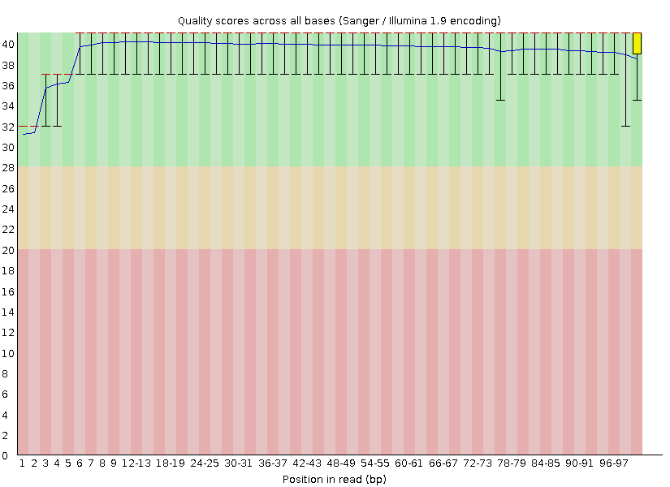

#R2

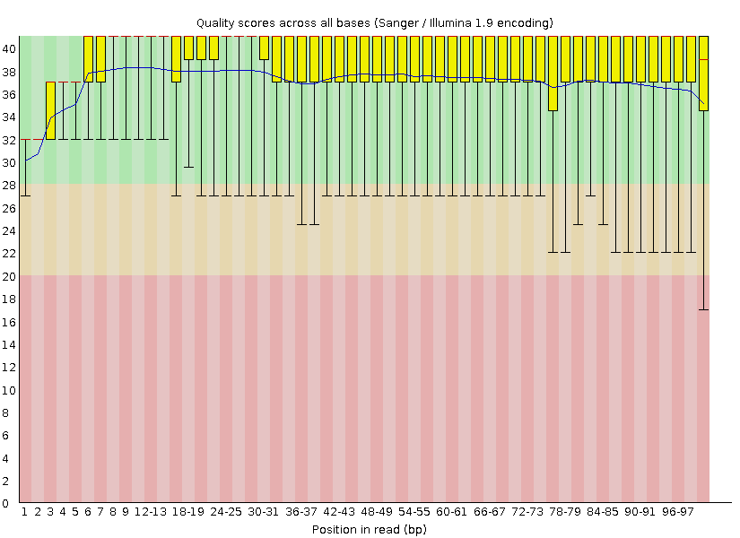

#R2

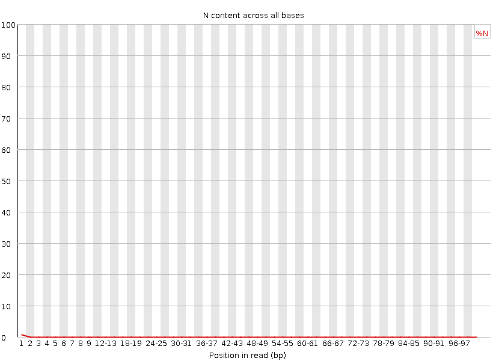

#10_2G_both_S8_L008

#R1

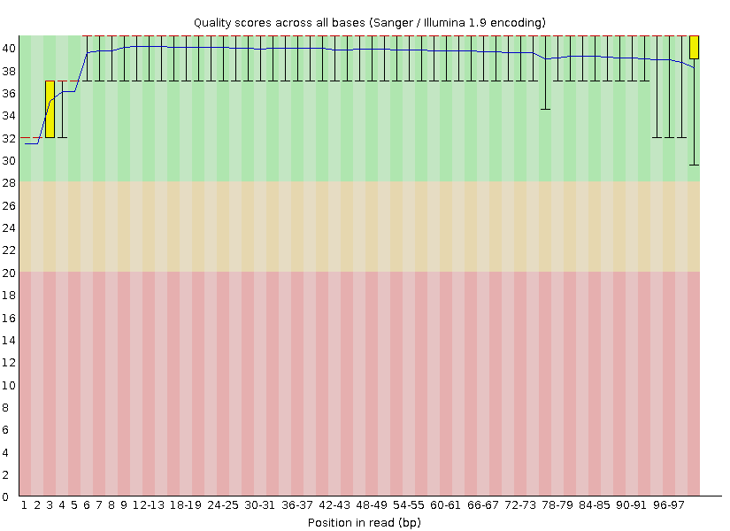

#R2

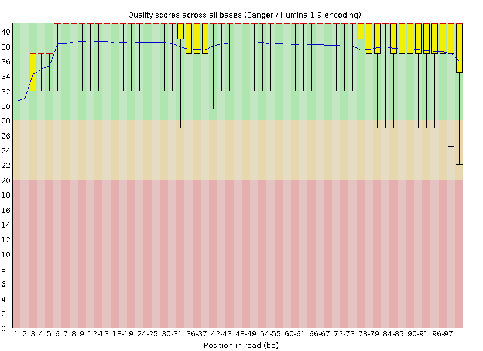

#R2

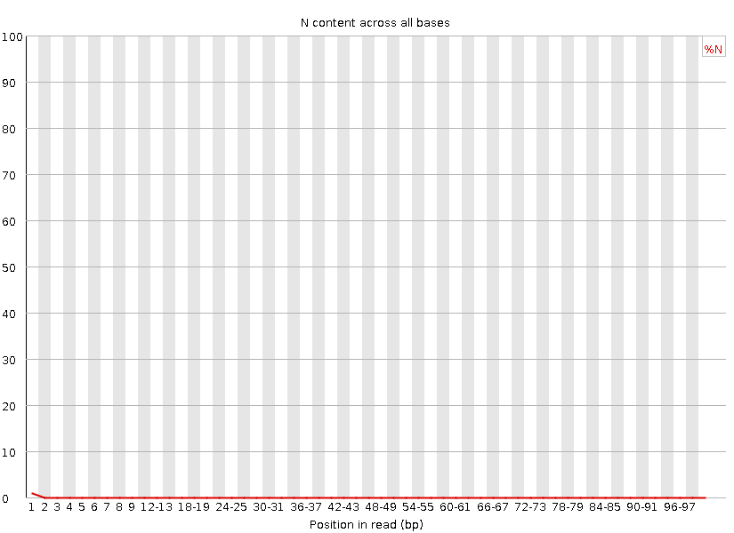

#1.1 The quality scores and per base n content are consistent across the both reads for both files. The quality scores for the R2(reverse compliment) reads are lower then the R1(forward) reads but this is to be expected since the R2 reads are sequenced later and sit on the sequencer long leading to sample degradation.

#1.2 Fastqc is significantly faster than running that my python script. This is likely because Fastqc is a streamlined program designed to elimante the inefficiencies that my code likely has. Presumably FastQC is limiting the amount of extra loops and other inefficient search methods used in its code so that it runs as fast as possible.

#1.3 The quality of both libraries is good. The forward reads are high quality. The reverse compliment reads are lower quality then would be ideal in cetain places with the scores dropping below 28.

PART 2 CUTADAPT #syntax cutadapt -a -A -o -p –cores <#of cores to use>

#actual command used (1/4) cutadapt -a AGATCGGAAGAGCACACGTCTGAACTCCAGTCA -A AGATCGGAAGAGCGTCGTGTAGGGAAAGAGTGT -o _rerun10g_R1_cutadapt -p rerun_10g_R2_cutadapt /projects/bgmp/shared/2017_sequencing/demultiplexed/10_2G_both_S8_L008_R1_001.fastq.gz /projects/bgmp/shared/2017_sequencing/demultiplexed/10_2G_both_S8_L008_R2_001.fastq.gz –cores 10

cutadapt -a AGATCGGAAGAGCACACGTCTGAACTCCAGTCA -A AGATCGGAAGAGCGTCGTGTAGGGAAAGAGTGT -o rerun31_R1_cutadapt -p rerun_31f_R2_cutadapt /projects/bgmp/shared/2017_sequencing/demultiplexed/31_4F_fox_S22_L008_R1_001.fastq.gz /projects/bgmp/shared/2017_sequencing/demultiplexed/31_4F_fox_S22_L008_R2_001.fastq.gz –cores 10

CUTADAPT NUMBER OF READS REMOVED

10_2G Files Total read pairs processed: 81,477,069 Read 1 with adapter: 2,131,954 (2.6%) Read 2 with adapter: 2,770,901 (3.4%)

31F Files === Summary ===

Total read pairs processed: 3,788,343 Read 1 with adapter: 456,168 (12.0%) Read 2 with adapter: 482,503 (12.7%) Pairs written (passing filters): 3,788,343 (100.0%)

2.6 TRIMMOMATIC #Bash command #actual command used 10g_R1_cutadapt 10g_R2_cutadapt 10_2g_R1_forward_paired 10_2g_R1_forward_unpaired 10_2g_R2_reverse_paired 10_2g_R2_reverse_unpaired LEADING:3 TRAILING:3 SLIDINGWINDOW:5:15 MINLEN:35

2.7 #Grab just the sequence line from fastq and compute distribution #Bash commoands

#cat 31_4f_R2_forward_paired |sed -n ‘2~4p’| awk ‘x=length($0) {print(x)}’ > count_10_R1_forward_paired

#sort | uniq -c | sort -n >

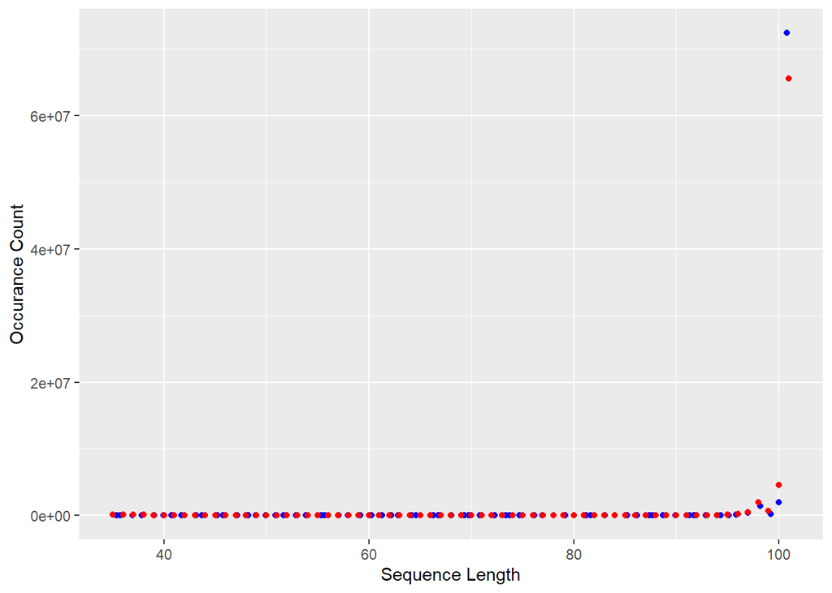

```r
library(ggplot2)
library(tidyverse)
df_10_R1 <- read.table("C:\\Users\\ano\\Desktop\\BGMP R Folder\\qaa r data\\dist_10_R1_paired.tsv")
df_10_R2 <- read.table("C:\\Users\\ano\\Desktop\\BGMP R Folder\\qaa r data\\dist_10_R2_paired.tsv")
df_30_R1 <- read.table("C:\\Users\\ano\\Desktop\\BGMP R Folder\\qaa r data\\dist_31_R1_paired.tsv")
df_30_R2 <- read.table("C:\\Users\\ano\\Desktop\\BGMP R Folder\\qaa r data\\dist_31_R2_paired.tsv")


ggplot(df_10_R1, aes(V2, V1)) +
  geom_point(color = 'blue', position = position_jitter()) +
  geom_point(data = df_10_R2, color = 'red', position = 'dodge') +
  labs(x = "Sequence Length", y = "Occurance Count")
```

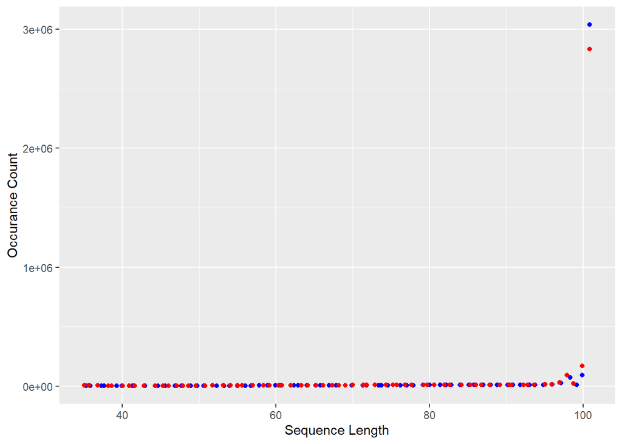

```r
ggplot(df_30_R1, aes(V2, V1)) +
  geom_point(color = 'blue', position = position_jitter()) +
  geom_point(data = df_30_R2, color = 'red', position = position_jitter()) +
  labs(x = "Sequence Length", y = "Occurance Count")
```

The graphs show nearly identical distributions for both the forward and reverse reads. There are slightly more long forward reads, this is likely because the reverse reads have to sit on the sequencer longer and so they degrade to shorter lengths, this is expected.

#3.11. HTSEQ #bash command htseq-count –stranded=yes

–nprocesses 16

actual command, ran this with –stranded=yes and –stranded=reverse for each of the two sam output files #htseq-count /projects/bgmp/ano/Bi622/qaa/qaaoutput/31samAligned.out.sam /projects/bgmp/ano/Bi622/qaa/qaaoutput/Mus_musculus.GRCm39.107.gtf –stranded=yes –nprocesses 16 -c 31_htseqout_stranded.tsv

3.12

HTSEQ 31_4f TOTAL 3597908 Mapped Forward 186062 (5.2%) Mapped Reverse 2957496(82.2%),

This sample is stranded since if it was unstranded we would see the same (or close to same) amount of mapped genes on both the forward and reverse files. Since there is a high degree of difference between the forward mapped genes (5.2%) and reverse mapped genes (82.2%) we know that there are genes in the reverse file that we mapped that we did not map in the forward mapping meaning that the sample is strand specific.

[output not shown]